# Impacto del Trabajo Remoto en la Salud Mental

[figure not shown]

> **Materia: Análisis Inteligente de Datos**  
> **Autor:** AgomferAustral  
> **Fecha:** 2024-12-08

**Precaución**

Falta que guarde los datos en la carpeta de reportes

**Advertencia**

Dejar la TOC para el final

# Introducción

El trabajo remoto ha emergido como una modalidad laboral predominante en la última década, intensificándose durante la pandemia de COVID-19. Esta transición ha generado un cambio significativo en la dinámica laboral, ofreciendo flexibilidad y comodidad, pero también planteando desafíos importantes para la salud mental de los empleados. A medida que las organizaciones adoptan el teletrabajo, surgen interrogantes sobre sus efectos en el bienestar psicológico de los trabajadores. Este trabajo tiene como objetivo analizar el impacto del trabajo remoto en la salud mental, utilizando un conjunto de datos que incluye variables demográficas, condiciones laborales y percepciones sobre el teletrabajo.

Los datos utilizados provienen de una encuesta realizada a trabajadores durante el año 2021, y se dispone de información sobre diversos factores que pueden influir en la salud mental, como el nivel de estrés, la satisfacción laboral y el equilibrio entre la vida laboral y personal. La fuente original de los datos, en formato CSV se puede obtener desde este [enlace](https://www.kaggle.com/datasets/waqi786/remote-work-and-mental-health) en el sitio de Kaggle.

# Metodología

Para llevar a cabo este análisis, se utilizará un enfoque cuali y cuantitativo basado en técnicas estadísticas que permitirán identificar correlaciones entre las variables del conjunto de datos, conocido como Análisis Exploratorio de Datos (EDA).  
Se explorarán las relaciones entre el **lugar de trabajo** (remoto vs. híbrido vs. tradicional), el **nivel de estrés**, las **condiciones de salud mental** reportadas y otros factores como la **frecuencia de reuniones virtuales** y el **acceso a recursos de salud mental**.

## Selección de Datos

Los datos crudos obtenidos de la fuente original, se encuentran en el archivo `Impact_of_Remote_Work_on_Mental_Health.csv` en la carpeta `datos_crudos`. Este archivo contiene información sobre la salud mental de los trabajadores en un contexto de trabajo remoto.

**Importante**

El directorio de trabajo esta definido en el proyecto, por lo que habria que abrir siempre el proyecto y no solo el archivo qmd

## Importación y Limpieza de Datos

El primer paso fundamental en cualquier análisis de datos es garantizar que la información con la que se trabaja sea confiable y esté preparada para ser procesada. A continuación, se describe el proceso aplicado para limpiar los datos relacionados con el impacto del trabajo remoto en la salud mental. Este procedimiento incluyó tanto la verificación inicial de la calidad de los datos como la eliminación de registros incompletos.

#### 1. **Carga de las bibliotecas necesarias e inicialización de carpetas de salida**

Antes de interactuar con los datos, se deben cargar las bibliotecas de R adecuadas. En este caso, se asume el uso de librerías como **`readr`** para la lectura de archivos CSV y el conjunto **`tidyverse`** para la manipulación de datos entre otras.

**Código**

```r
# Cargar librerías necesarias

cargar_paquetes <- function(pckgs){
  # cargar los paquetes e instalarlos (de ser necesario)
  #
  # Argumentos:
  #   pckgs: con el nombre de los paquetes
  new_packages     <- pckgs[!(pckgs %in% installed.packages()[, "Package"])]
  if(length(new_packages)) { install.packages(new_packages) }
  for (pckg in pckgs) {
    suppressMessages(library(pckg, character.only = TRUE) )
  }
}

cargar_paquetes(
  c("tidyverse","dplyr", "readr", "knitr", "ggplot2","corrplot","sf", "spData","RColorBrewer")
)



# Crear directorios de salida si no existen
dir.create("../datos_salida", showWarnings = FALSE)
dir.create("../resultados/graficos", showWarnings = FALSE)
```

Estas bibliotecas ofrecen funciones eficaces para manejar y transformar conjuntos de datos de manera fluida.

#### 2. **Lectura de los datos**

Los datos se cargaron desde un archivo externo en formato CSV utilizando la función `read_csv()` de la librería **`readr`**. El archivo se encuentra en un directorio relativo, y se asignó a un objeto llamado `datos`.

**Tip**

El directorio de trabajo es codigo, por lo que todas las referencias a directorios comenzaran con ../

**Código**

```r
# Leer los datos

datos <- read_csv("../datos_crudos/Impact_of_Remote_Work_on_Mental_Health.csv")
```

#### 3. Exploración inicial de los datos

- str(datos): Muestra una descripción compacta del objeto, incluyendo las variables, sus tipos de datos y algunos valores representativos.
- spec(datos): Detalla la especificación de las columnas, útil para confirmar que las clases de datos coinciden con las expectativas.
- glimpse(datos): Proporciona una vista general más legible de las variables y valores, con un formato horizontal.
- summary(datos): Entrega un resumen de las métricas estadísticas básicas de cada variable, dependiendo del tipo de cada variable.

Estas funciones permiten detectar problemas iniciales, como datos mal tipados o la presencia de valores inesperados.

**Código**

```r
# Exploracion inicial de la estructura de datos

str(datos)
```

```
spc_tbl_ [5,000 × 20] (S3: spec_tbl_df/tbl_df/tbl/data.frame)
 $ Employee_ID                      : chr [1:5000] "EMP0001" "EMP0002" "EMP0003" "EMP0004" ...
 $ Age                              : num [1:5000] 32 40 59 27 49 59 31 42 56 30 ...
 $ Gender                           : chr [1:5000] "Non-binary" "Female" "Non-binary" "Male" ...
 $ Job_Role                         : chr [1:5000] "HR" "Data Scientist" "Software Engineer" "Software Engineer" ...
 $ Industry                         : chr [1:5000] "Healthcare" "IT" "Education" "Finance" ...
 $ Years_of_Experience              : num [1:5000] 13 3 22 20 32 31 24 6 9 28 ...
 $ Work_Location                    : chr [1:5000] "Hybrid" "Remote" "Hybrid" "Onsite" ...
 $ Hours_Worked_Per_Week            : num [1:5000] 47 52 46 32 35 39 51 54 24 57 ...
 $ Number_of_Virtual_Meetings       : num [1:5000] 7 4 11 8 12 3 7 7 4 6 ...
 $ Work_Life_Balance_Rating         : num [1:5000] 2 1 5 4 2 4 3 3 2 1 ...
 $ Stress_Level                     : chr [1:5000] "Medium" "Medium" "Medium" "High" ...
 $ Mental_Health_Condition          : chr [1:5000] "Depression" "Anxiety" "Anxiety" "Depression" ...
 $ Access_to_Mental_Health_Resources: chr [1:5000] "No" "No" "No" "Yes" ...
 $ Productivity_Change              : chr [1:5000] "Decrease" "Increase" "No Change" "Increase" ...
 $ Social_Isolation_Rating          : num [1:5000] 1 3 4 3 3 5 5 5 2 2 ...
 $ Satisfaction_with_Remote_Work    : chr [1:5000] "Unsatisfied" "Satisfied" "Unsatisfied" "Unsatisfied" ...
 $ Company_Support_for_Remote_Work  : num [1:5000] 1 2 5 3 3 1 3 4 4 1 ...
 $ Physical_Activity                : chr [1:5000] "Weekly" "Weekly" "None" "None" ...
 $ Sleep_Quality                    : chr [1:5000] "Good" "Good" "Poor" "Poor" ...
 $ Region                           : chr [1:5000] "Europe" "Asia" "North America" "Europe" ...
 - attr(*, "spec")=
  .. cols(
  ..   Employee_ID = col_character(),
  ..   Age = col_double(),
  ..   Gender = col_character(),
  ..   Job_Role = col_character(),
  ..   Industry = col_character(),
  ..   Years_of_Experience = col_double(),
  ..   Work_Location = col_character(),
  ..   Hours_Worked_Per_Week = col_double(),
  ..   Number_of_Virtual_Meetings = col_double(),
  ..   Work_Life_Balance_Rating = col_double(),
  ..   Stress_Level = col_character(),
  ..   Mental_Health_Condition = col_character(),
  ..   Access_to_Mental_Health_Resources = col_character(),
  ..   Productivity_Change = col_character(),
  ..   Social_Isolation_Rating = col_double(),
  ..   Satisfaction_with_Remote_Work = col_character(),
  ..   Company_Support_for_Remote_Work = col_double(),
  ..   Physical_Activity = col_character(),
  ..   Sleep_Quality = col_character(),
  ..   Region = col_character()
  .. )
 - attr(*, "problems")=<externalptr>
```

**Código**

```r
spec(datos)
```

[output not shown]

**Código**

```r
glimpse(datos)
```

```
Rows: 5,000
Columns: 20
$ Employee_ID                       <chr> "EMP0001", "EMP0002", "EMP0003", "EM…
$ Age                               <dbl> 32, 40, 59, 27, 49, 59, 31, 42, 56, …
$ Gender                            <chr> "Non-binary", "Female", "Non-binary"…
$ Job_Role                          <chr> "HR", "Data Scientist", "Software En…
$ Industry                          <chr> "Healthcare", "IT", "Education", "Fi…
$ Years_of_Experience               <dbl> 13, 3, 22, 20, 32, 31, 24, 6, 9, 28,…
$ Work_Location                     <chr> "Hybrid", "Remote", "Hybrid", "Onsit…
$ Hours_Worked_Per_Week             <dbl> 47, 52, 46, 32, 35, 39, 51, 54, 24, …
$ Number_of_Virtual_Meetings        <dbl> 7, 4, 11, 8, 12, 3, 7, 7, 4, 6, 3, 1…
$ Work_Life_Balance_Rating          <dbl> 2, 1, 5, 4, 2, 4, 3, 3, 2, 1, 3, 4, …
$ Stress_Level                      <chr> "Medium", "Medium", "Medium", "High"…
$ Mental_Health_Condition           <chr> "Depression", "Anxiety", "Anxiety", …
$ Access_to_Mental_Health_Resources <chr> "No", "No", "No", "Yes", "Yes", "No"…
$ Productivity_Change               <chr> "Decrease", "Increase", "No Change",…
$ Social_Isolation_Rating           <dbl> 1, 3, 4, 3, 3, 5, 5, 5, 2, 2, 4, 4, …
$ Satisfaction_with_Remote_Work     <chr> "Unsatisfied", "Satisfied", "Unsatis…
$ Company_Support_for_Remote_Work   <dbl> 1, 2, 5, 3, 3, 1, 3, 4, 4, 1, 2, 3, …
$ Physical_Activity                 <chr> "Weekly", "Weekly", "None", "None", …
$ Sleep_Quality                     <chr> "Good", "Good", "Poor", "Poor", "Ave…
$ Region                            <chr> "Europe", "Asia", "North America", "…
```

**Código**

```r
summary(datos)
```

```
 Employee_ID             Age           Gender            Job_Role
 Length:5000        Min.   :22.00   Length:5000        Length:5000
 Class :character   1st Qu.:31.00   Class :character   Class :character
 Mode  :character   Median :41.00   Mode  :character   Mode  :character
                    Mean   :40.99
                    3rd Qu.:51.00
                    Max.   :60.00
   Industry         Years_of_Experience Work_Location
 Length:5000        Min.   : 1.00       Length:5000
 Class :character   1st Qu.: 9.00       Class :character
 Mode  :character   Median :18.00       Mode  :character
                    Mean   :17.81
                    3rd Qu.:26.00
                    Max.   :35.00
 Hours_Worked_Per_Week Number_of_Virtual_Meetings Work_Life_Balance_Rating
 Min.   :20.00         Min.   : 0.000             Min.   :1.000
 1st Qu.:29.00         1st Qu.: 4.000             1st Qu.:2.000
 Median :40.00         Median : 8.000             Median :3.000
 Mean   :39.61         Mean   : 7.559             Mean   :2.984
 3rd Qu.:50.00         3rd Qu.:12.000             3rd Qu.:4.000
 Max.   :60.00         Max.   :15.000             Max.   :5.000
 Stress_Level       Mental_Health_Condition Access_to_Mental_Health_Resources
 Length:5000        Length:5000             Length:5000
 Class :character   Class :character        Class :character
 Mode  :character   Mode  :character        Mode  :character



 Productivity_Change Social_Isolation_Rating Satisfaction_with_Remote_Work
 Length:5000         Min.   :1.000           Length:5000
 Class :character    1st Qu.:2.000           Class :character
 Mode  :character    Median :3.000           Mode  :character
                     Mean   :2.994
                     3rd Qu.:4.000
                     Max.   :5.000
 Company_Support_for_Remote_Work Physical_Activity  Sleep_Quality
 Min.   :1.000                   Length:5000        Length:5000
 1st Qu.:2.000                   Class :character   Class :character
 Median :3.000                   Mode  :character   Mode  :character
 Mean   :3.008
 3rd Qu.:4.000
 Max.   :5.000
    Region
 Length:5000
 Class :character
 Mode  :character
```

#### 4. Limpieza y transformación de datos

La limpieza y transformación de datos es un paso crítico en cualquier análisis, ya que garantiza que la información sea consistente, completa y utilizable. En este caso, se eliminaron las filas con valores faltantes utilizando la función `drop_na()`, lo que permite trabajar únicamente con registros completos y confiables. Este paso es esencial para evitar sesgos derivados de datos ausentes y asegurar la calidad del análisis. Además, se recomienda revisar posibles inconsistencias en los datos, como valores duplicados o fuera de rango, y aplicar transformaciones necesarias, como estandarizar unidades o corregir errores tipográficos. Estas acciones contribuyen a que los datos sean adecuados para los métodos estadísticos y modelos que se implementarán posteriormente. La limpieza también facilita la interpretación de los resultados al eliminar posibles interferencias causadas por datos incorrectos o incompletos.

**Código**

```r
datos_limpios <- datos %>% drop_na()

# Comprobar si se realizaron cambios

kable(summary(datos_limpios))
```

|  | Employee_ID | Age | Gender | Job_Role | Industry | Years_of_Experience | Work_Location | Hours_Worked_Per_Week | Number_of_Virtual_Meetings | Work_Life_Balance_Rating | Stress_Level | Mental_Health_Condition | Access_to_Mental_Health_Resources | Productivity_Change | Social_Isolation_Rating | Satisfaction_with_Remote_Work | Company_Support_for_Remote_Work | Physical_Activity | Sleep_Quality | Region |
| --- | --- | --- | --- | --- | --- | --- | --- | --- | --- | --- | --- | --- | --- | --- | --- | --- | --- | --- | --- | --- |
|  | Length:5000 | Min. :22.00 | Length:5000 | Length:5000 | Length:5000 | Min. : 1.00 | Length:5000 | Min. :20.00 | Min. : 0.000 | Min. :1.000 | Length:5000 | Length:5000 | Length:5000 | Length:5000 | Min. :1.000 | Length:5000 | Min. :1.000 | Length:5000 | Length:5000 | Length:5000 |
|  | Class :character | 1st Qu.:31.00 | Class :character | Class :character | Class :character | 1st Qu.: 9.00 | Class :character | 1st Qu.:29.00 | 1st Qu.: 4.000 | 1st Qu.:2.000 | Class :character | Class :character | Class :character | Class :character | 1st Qu.:2.000 | Class :character | 1st Qu.:2.000 | Class :character | Class :character | Class :character |
|  | Mode :character | Median :41.00 | Mode :character | Mode :character | Mode :character | Median :18.00 | Mode :character | Median :40.00 | Median : 8.000 | Median :3.000 | Mode :character | Mode :character | Mode :character | Mode :character | Median :3.000 | Mode :character | Median :3.000 | Mode :character | Mode :character | Mode :character |
|  | NA | Mean :40.99 | NA | NA | NA | Mean :17.81 | NA | Mean :39.61 | Mean : 7.559 | Mean :2.984 | NA | NA | NA | NA | Mean :2.994 | NA | Mean :3.008 | NA | NA | NA |
|  | NA | 3rd Qu.:51.00 | NA | NA | NA | 3rd Qu.:26.00 | NA | 3rd Qu.:50.00 | 3rd Qu.:12.000 | 3rd Qu.:4.000 | NA | NA | NA | NA | 3rd Qu.:4.000 | NA | 3rd Qu.:4.000 | NA | NA | NA |
|  | NA | Max. :60.00 | NA | NA | NA | Max. :35.00 | NA | Max. :60.00 | Max. :15.000 | Max. :5.000 | NA | NA | NA | NA | Max. :5.000 | NA | Max. :5.000 | NA | NA | NA |

Se elimina la columna de datos de identificadores ya que no tienen valor estadístico para este caso.

**Código**

```r
# Eliminación de columna de identificadores
datos <- datos %>%
  select(-Employee_ID)  # Elimina la columna Employee_ID
```

##### Verificación de valores únicos en variables categóricas

Es fundamental revisar los valores únicos presentes en las variables categóricas para identificar inconsistencias o categorías mal definidas. Por ejemplo, errores tipográficos en categorías como “Remote” y “Rremote” podrían sesgar los resultados del análisis. La función unique() en R permite inspeccionar estos valores, mientras que herramientas como table() ayudan a visualizar la frecuencia de cada categoría. Además, detectar valores categóricos que aparecen con muy poca frecuencia es crucial, ya que pueden requerir un agrupamiento con otras categorías para mejorar la robustez de los modelos. Este paso garantiza que las variables categóricas reflejen adecuadamente las características analizadas y minimiza problemas en etapas posteriores del análisis.

**Código**

```r
# Verificar valores únicos en Social_Isolation_Rating
valores_unicos_sir <- unique(datos$Social_Isolation_Rating)
respuesta <- tibble("Valores únicos en Social_Isolation_Rating:",
            valores_unicos_sir)

kable(respuesta)
```

| “Valores únicos en Social_Isolation_Rating:” | valores_unicos_sir |
| --- | --- |
| Valores únicos en Social_Isolation_Rating: | 1 |
| Valores únicos en Social_Isolation_Rating: | 3 |
| Valores únicos en Social_Isolation_Rating: | 4 |
| Valores únicos en Social_Isolation_Rating: | 5 |
| Valores únicos en Social_Isolation_Rating: | 2 |

**Código**

```r
# Verificar valores únicos en Work_Life_Balance_Rating
valores_unicos_wlb <- unique(datos$Work_Life_Balance_Rating)
respuesta <- tibble("Valores únicos en Work_Life_Balance_Rating:",
                    valores_unicos_wlb)

# Verificar valores únicos en Satisfaction_with_Remote_Work
valores_unicos_srw <- unique(datos$Satisfaction_with_Remote_Work)
respuesta <- tibble("Valores únicos en Satisfaction_with_Remote_Work:",
                    valores_unicos_srw)

kable(respuesta)
```

| “Valores únicos en Satisfaction_with_Remote_Work:” | valores_unicos_srw |
| --- | --- |
| Valores únicos en Satisfaction_with_Remote_Work: | Unsatisfied |
| Valores únicos en Satisfaction_with_Remote_Work: | Satisfied |
| Valores únicos en Satisfaction_with_Remote_Work: | Neutral |

**Código**

```r
# Verificar valores únicos en Company_Support_for_Remote_Work
valores_unicos_csrw <- unique(datos$Company_Support_for_Remote_Work)
respuesta <- tibble("Valores únicos en Company_Support_for_Remote_Work:",    valores_unicos_csrw)

kable(respuesta)
```

| “Valores únicos en Company_Support_for_Remote_Work:” | valores_unicos_csrw |
| --- | --- |
| Valores únicos en Company_Support_for_Remote_Work: | 1 |
| Valores únicos en Company_Support_for_Remote_Work: | 2 |
| Valores únicos en Company_Support_for_Remote_Work: | 5 |
| Valores únicos en Company_Support_for_Remote_Work: | 3 |
| Valores únicos en Company_Support_for_Remote_Work: | 4 |

**Código**

```r
# Verificar valores únicos en Company_Support_for_Remote_Work
valores_unicos_sl <- unique(datos$Stress_Level)
respuesta <- tibble("Valores únicos en Stress_Level:",
                    valores_unicos_sl)

kable(respuesta)
```

| “Valores únicos en Stress_Level:” | valores_unicos_sl |
| --- | --- |
| Valores únicos en Stress_Level: | Medium |
| Valores únicos en Stress_Level: | High |
| Valores únicos en Stress_Level: | Low |

##### Conversión a variables categóricas nominales u ordinales

Las variables categóricas deben ser clasificadas como nominales u ordinales según su naturaleza, para garantizar una representación correcta en el análisis. Las variables nominales, como el género o la ubicación de trabajo, no tienen un orden inherente y pueden ser manejadas como factores en R. Por otro lado, las variables ordinales, como las puntuaciones de satisfacción o balance vida-trabajo, implican una jerarquía y requieren ser definidas como factores con niveles ordenados. En R, la función `factor()` permite establecer los niveles y, si es necesario, especificar un orden. Esta clasificación adecuada no solo mejora la precisión de los modelos estadísticos, sino que también optimiza la interpretación de los resultados, especialmente en análisis que dependen de relaciones jerárquicas o asociaciones categóricas.

**Código**

```r
# Convertimos a factores los datos de tipo caracter que corresponde

datos <- datos %>%
  mutate(
    Gender = as_factor(Gender),
    Job_Role = as_factor(Job_Role),
    Industry = as_factor(Industry),
    Work_Location = as_factor(Work_Location),
    Mental_Health_Condition = as_factor(Mental_Health_Condition),
    Access_to_Mental_Health_Resources = factor(Access_to_Mental_Health_Resources, levels = c("No", "Yes")),
    Region = as_factor(Region),

    # Mapeo de valores numéricos a palabras para Social_Isolation_Rating
    Social_Isolation_Rating = factor(recode(Social_Isolation_Rating,
                                      `1` = "Connected",
                                      `2` = "Slightly",
                                      `3` = "Moderately",
                                      `4` = "Highly",
                                      `5` = "Completely"),
                                     ordered = TRUE,
                                     levels = c("Connected", "Slightly", "Moderately", "Highly", "Completely")
                                     ),

    # Mapeo de valores numéricos a palabras para Work_Life_Balance_Rating
    Work_Life_Balance_Rating = factor(recode(Work_Life_Balance_Rating,
                                       `1` = "Bad",
                                       `2` = "Poor",
                                       `3` = "Average",
                                       `4` = "Good",
                                       `5` = "Excellent"),
                                      ordered = TRUE,
                                      levels = c("Bad", "Poor", "Average", "Good", "Excellent")
                                      ),

    # Mapeo de valores numéricos a palabras para Company_Support_for_Remote_Work
    Company_Support_for_Remote_Work = factor(recode(Company_Support_for_Remote_Work,
                                              `1` = "Bad",
                                              `2` = "Poor",
                                              `3` = "Average",
                                              `4` = "Good",
                                              `5` = "Excellent"),
                                             ordered = TRUE,
                                             levels = c("Bad", "Poor", "Average", "Good", "Excellent")
                                             ),

    # Conversión de Satisfaction_with_Remote_Work a factor
    Satisfaction_with_Remote_Work = factor(Satisfaction_with_Remote_Work, ordered = TRUE, levels = c("Unsatisfied", "Neutral", "Satisfied")),

    Productivity_Change = factor(Productivity_Change, ordered = TRUE, levels = c("Decrease","No Change", "Increase")),

    Physical_Activity = factor(Physical_Activity, ordered = TRUE, levels = c("None", "Weekly","Daily")),

    Sleep_Quality = factor(Sleep_Quality, ordered = TRUE, levels = c("Poor","Average","Good")),

    Stress_Level = factor(Stress_Level, ordered = TRUE, levels = c("Low","Medium","High"))
  )

# Verificar los resultados
kable(head(datos))
```

| Age | Gender | Job_Role | Industry | Years_of_Experience | Work_Location | Hours_Worked_Per_Week | Number_of_Virtual_Meetings | Work_Life_Balance_Rating | Stress_Level | Mental_Health_Condition | Access_to_Mental_Health_Resources | Productivity_Change | Social_Isolation_Rating | Satisfaction_with_Remote_Work | Company_Support_for_Remote_Work | Physical_Activity | Sleep_Quality | Region |
| --- | --- | --- | --- | --- | --- | --- | --- | --- | --- | --- | --- | --- | --- | --- | --- | --- | --- | --- |
| 32 | Non-binary | HR | Healthcare | 13 | Hybrid | 47 | 7 | Poor | Medium | Depression | No | Decrease | Connected | Unsatisfied | Bad | Weekly | Good | Europe |
| 40 | Female | Data Scientist | IT | 3 | Remote | 52 | 4 | Bad | Medium | Anxiety | No | Increase | Moderately | Satisfied | Poor | Weekly | Good | Asia |
| 59 | Non-binary | Software Engineer | Education | 22 | Hybrid | 46 | 11 | Excellent | Medium | Anxiety | No | No Change | Highly | Unsatisfied | Excellent | None | Poor | North America |
| 27 | Male | Software Engineer | Finance | 20 | Onsite | 32 | 8 | Good | High | Depression | Yes | Increase | Moderately | Unsatisfied | Average | None | Poor | Europe |
| 49 | Male | Sales | Consulting | 32 | Onsite | 35 | 12 | Poor | High | None | Yes | Decrease | Moderately | Unsatisfied | Average | Weekly | Average | North America |
| 59 | Non-binary | Sales | IT | 31 | Hybrid | 39 | 3 | Good | High | None | No | Increase | Completely | Unsatisfied | Bad | None | Average | South America |

**Código**

```r
glimpse(datos)
```

```
Rows: 5,000
Columns: 19
$ Age                               <dbl> 32, 40, 59, 27, 49, 59, 31, 42, 56, …
$ Gender                            <fct> Non-binary, Female, Non-binary, Male…
$ Job_Role                          <fct> HR, Data Scientist, Software Enginee…
$ Industry                          <fct> Healthcare, IT, Education, Finance, …
$ Years_of_Experience               <dbl> 13, 3, 22, 20, 32, 31, 24, 6, 9, 28,…
$ Work_Location                     <fct> Hybrid, Remote, Hybrid, Onsite, Onsi…
$ Hours_Worked_Per_Week             <dbl> 47, 52, 46, 32, 35, 39, 51, 54, 24, …
$ Number_of_Virtual_Meetings        <dbl> 7, 4, 11, 8, 12, 3, 7, 7, 4, 6, 3, 1…
$ Work_Life_Balance_Rating          <ord> Poor, Bad, Excellent, Good, Poor, Go…
$ Stress_Level                      <ord> Medium, Medium, Medium, High, High, …
$ Mental_Health_Condition           <fct> Depression, Anxiety, Anxiety, Depres…
$ Access_to_Mental_Health_Resources <fct> No, No, No, Yes, Yes, No, Yes, No, Y…
$ Productivity_Change               <ord> Decrease, Increase, No Change, Incre…
$ Social_Isolation_Rating           <ord> Connected, Moderately, Highly, Moder…
$ Satisfaction_with_Remote_Work     <ord> Unsatisfied, Satisfied, Unsatisfied,…
$ Company_Support_for_Remote_Work   <ord> Bad, Poor, Excellent, Average, Avera…
$ Physical_Activity                 <ord> Weekly, Weekly, None, None, Weekly, …
$ Sleep_Quality                     <ord> Good, Good, Poor, Poor, Average, Ave…
$ Region                            <fct> Europe, Asia, North America, Europe,…
```

**Código**

```r
# Eliminar filas con valores faltantes
datos_limpios <- datos %>%
  drop_na()

glimpse(datos_limpios)
```

```
Rows: 5,000
Columns: 19
$ Age                               <dbl> 32, 40, 59, 27, 49, 59, 31, 42, 56, …
$ Gender                            <fct> Non-binary, Female, Non-binary, Male…
$ Job_Role                          <fct> HR, Data Scientist, Software Enginee…
$ Industry                          <fct> Healthcare, IT, Education, Finance, …
$ Years_of_Experience               <dbl> 13, 3, 22, 20, 32, 31, 24, 6, 9, 28,…
$ Work_Location                     <fct> Hybrid, Remote, Hybrid, Onsite, Onsi…
$ Hours_Worked_Per_Week             <dbl> 47, 52, 46, 32, 35, 39, 51, 54, 24, …
$ Number_of_Virtual_Meetings        <dbl> 7, 4, 11, 8, 12, 3, 7, 7, 4, 6, 3, 1…
$ Work_Life_Balance_Rating          <ord> Poor, Bad, Excellent, Good, Poor, Go…
$ Stress_Level                      <ord> Medium, Medium, Medium, High, High, …
$ Mental_Health_Condition           <fct> Depression, Anxiety, Anxiety, Depres…
$ Access_to_Mental_Health_Resources <fct> No, No, No, Yes, Yes, No, Yes, No, Y…
$ Productivity_Change               <ord> Decrease, Increase, No Change, Incre…
$ Social_Isolation_Rating           <ord> Connected, Moderately, Highly, Moder…
$ Satisfaction_with_Remote_Work     <ord> Unsatisfied, Satisfied, Unsatisfied,…
$ Company_Support_for_Remote_Work   <ord> Bad, Poor, Excellent, Average, Avera…
$ Physical_Activity                 <ord> Weekly, Weekly, None, None, Weekly, …
$ Sleep_Quality                     <ord> Good, Good, Poor, Poor, Average, Ave…
$ Region                            <fct> Europe, Asia, North America, Europe,…
```

**Código**

```r
# Guardar los datos limpios
write_csv(datos_limpios, "../datos_limpios/datos_limpios.csv")
```

# Análisis descriptivo

El análisis descriptivo es un componente esencial para explorar y comprender las características fundamentales de un conjunto de datos. En el contexto del impacto del trabajo remoto en la salud mental, este tipo de análisis proporciona una visión inicial sobre las distribuciones de las variables clave, así como posibles patrones o relaciones entre ellas. A través de estadísticos descriptivos como medias, medianas, y frecuencias, se busca identificar tendencias generales, como el promedio de horas trabajadas por semana o las distribuciones de estrés según la modalidad laboral. Además, el análisis descriptivo incluye la exploración de variables categóricas, como la satisfacción con el trabajo remoto o la disponibilidad de recursos de salud mental, para detectar diferencias entre grupos. Este enfoque permite identificar problemas iniciales, como sesgos en la representación de ciertos subgrupos (por ejemplo, géneros o industrias específicas) y ayuda a plantear hipótesis más informadas para análisis posteriores. En esta etapa también se elaboran visualizaciones simples, como histogramas o diagramas de barras, para facilitar la interpretación de los datos y comunicar los hallazgos iniciales de manera clara y efectiva. Este análisis preliminar es crucial para estructurar el estudio y sentar las bases de decisiones analíticas más complejas.

## Variables numéricas

**Código**

```r
# Resumen estadístico de las variables numéricas
resumen_estadistico <- datos_limpios %>%
  summarise(
    across(where(is.numeric),
          list(media = \(x) mean(x, na.rm = TRUE),
               mediana = \(x) median(x, na.rm = TRUE),
               desvio = \(x) sd(x, na.rm = TRUE),
               minimo = \(x) min(x, na.rm = TRUE),
               máximo = \(x) max(x, na.rm = TRUE)))
  )

# Presentar el resumen en una tabla
kable(t(resumen_estadistico))
```

| Age_media | 40.995000 |
| --- | --- |
| Age_mediana | 41.000000 |
| Age_desvio | 11.296021 |
| Age_minimo | 22.000000 |
| Age_máximo | 60.000000 |
| Years_of_Experience_media | 17.810200 |
| Years_of_Experience_mediana | 18.000000 |
| Years_of_Experience_desvio | 10.020412 |
| Years_of_Experience_minimo | 1.000000 |
| Years_of_Experience_máximo | 35.000000 |
| Hours_Worked_Per_Week_media | 39.614600 |
| Hours_Worked_Per_Week_mediana | 40.000000 |
| Hours_Worked_Per_Week_desvio | 11.860194 |
| Hours_Worked_Per_Week_minimo | 20.000000 |
| Hours_Worked_Per_Week_máximo | 60.000000 |
| Number_of_Virtual_Meetings_media | 7.559000 |
| Number_of_Virtual_Meetings_mediana | 8.000000 |
| Number_of_Virtual_Meetings_desvio | 4.636121 |
| Number_of_Virtual_Meetings_minimo | 0.000000 |
| Number_of_Virtual_Meetings_máximo | 15.000000 |

**Código**

```r
# Guardar el resumen estadístico
write_csv(resumen_estadistico, "../datos_salida/resumen_estadistico.csv")
```

## Correlación de variables numéricas

La correlación mide la fuerza y dirección de la relación lineal entre dos variables numéricas. Representada por el coeficiente de correlación de Pearson (r), su valor oscila entre -1 y 1: un valor positivo indica una relación directa, mientras que uno negativo sugiere una relación inversa. Valores cercanos a 0 reflejan poca o ninguna relación. Esta métrica es útil para identificar asociaciones potenciales, como el impacto del número de reuniones virtuales en el estrés laboral. Aunque es una herramienta poderosa, la correlación no implica causalidad, por lo que debe interpretarse con precaución en el contexto del análisis.

**Código**

```r
# Paso 1: Filtrar las columnas numéricas
datos_numericos <- datos_limpios %>%
  select_if(is.numeric)

# Paso 2: Calcular la matriz de correlación
matriz_correlacion <- cor(datos_numericos, use = "complete.obs")

kable(matriz_correlacion)
```

|  | Age | Years_of_Experience | Hours_Worked_Per_Week | Number_of_Virtual_Meetings |
| --- | --- | --- | --- | --- |
| Age | 1.0000000 | -0.0044796 | -0.0013522 | 0.0036172 |
| Years_of_Experience | -0.0044796 | 1.0000000 | -0.0185368 | 0.0190434 |
| Hours_Worked_Per_Week | -0.0013522 | -0.0185368 | 1.0000000 | -0.0046087 |
| Number_of_Virtual_Meetings | 0.0036172 | 0.0190434 | -0.0046087 | 1.0000000 |

## Variables categoricas

El resumen de frecuencias y proporciones de variables categóricas es crucial para comprender la distribución de las diferentes categorías en el conjunto de datos. Con estas tablas, se observa cuántos casos pertenecen a cada categoría, como el género o la modalidad de trabajo. También se calcularon proporciones para determinar qué porcentaje del total representa cada categoría. Este análisis es útil para detectar posibles desequilibrios en la representación de subgrupos y proporciona una visión clara de la composición de los datos, lo que facilita la identificación de patrones y la interpretación de los resultados.

### Variables categóricas nominales

Para las variables categóricas nominales, el resumen de frecuencias y proporciones ofrece una visión sobre la distribución de categorías sin un orden específico, como el género o la modalidad de trabajo. Este análisis ayuda a detectar la representación relativa de cada categoría y permite evaluar la diversidad o el sesgo en los datos.

**Código**

```r
# Identificar variables nominales
nominales <- datos_limpios %>%
  select(where(is.factor) & !where(is.ordered)) %>%
  names()

# Resumen para variables nominales
resumen_nominales <- datos_limpios %>%
  select(all_of(nominales)) %>%
  pivot_longer(cols = everything(), names_to = "Variable", values_to = "Categoría") %>%
  group_by(Variable, Categoría) %>%
  summarise(
    Frecuencia = n(),
    Proporción = Frecuencia / nrow(datos_limpios),
    .groups = "drop"
  )

# Mostrar resúmenes
kable(resumen_nominales, caption = "Resumen de variables nominales")
```

Resumen de variables nominales

| Variable | Categoría | Frecuencia | Proporción |
| --- | --- | --- | --- |
| Access_to_Mental_Health_Resources | No | 2553 | 0.5106 |
| Access_to_Mental_Health_Resources | Yes | 2447 | 0.4894 |
| Gender | Non-binary | 1214 | 0.2428 |
| Gender | Female | 1274 | 0.2548 |
| Gender | Male | 1270 | 0.2540 |
| Gender | Prefer not to say | 1242 | 0.2484 |
| Industry | Healthcare | 728 | 0.1456 |
| Industry | IT | 746 | 0.1492 |
| Industry | Education | 690 | 0.1380 |
| Industry | Finance | 747 | 0.1494 |
| Industry | Consulting | 680 | 0.1360 |
| Industry | Manufacturing | 683 | 0.1366 |
| Industry | Retail | 726 | 0.1452 |
| Job_Role | HR | 716 | 0.1432 |
| Job_Role | Data Scientist | 696 | 0.1392 |
| Job_Role | Software Engineer | 711 | 0.1422 |
| Job_Role | Sales | 733 | 0.1466 |
| Job_Role | Marketing | 683 | 0.1366 |
| Job_Role | Designer | 723 | 0.1446 |
| Job_Role | Project Manager | 738 | 0.1476 |
| Mental_Health_Condition | Depression | 1246 | 0.2492 |
| Mental_Health_Condition | Anxiety | 1278 | 0.2556 |
| Mental_Health_Condition | None | 1196 | 0.2392 |
| Mental_Health_Condition | Burnout | 1280 | 0.2560 |
| Region | Europe | 840 | 0.1680 |
| Region | Asia | 829 | 0.1658 |
| Region | North America | 777 | 0.1554 |
| Region | South America | 827 | 0.1654 |
| Region | Oceania | 867 | 0.1734 |
| Region | Africa | 860 | 0.1720 |
| Work_Location | Hybrid | 1649 | 0.3298 |
| Work_Location | Remote | 1714 | 0.3428 |
| Work_Location | Onsite | 1637 | 0.3274 |

**Código**

```r
# Guardar el resumen estadístico
write_csv(resumen_nominales, "../datos_salida/resumen_nominales.csv")

# Ordenar por distancia las modalidades laborales
datos_limpios$Work_Location <- factor(datos_limpios$Work_Location, levels = c("Remote", "Hybrid", "Onsite"))
```

### Variables categóricas ordinales

El resumen de frecuencias y proporciones de variables categóricas ordinales permite observar la distribución de categorías con un orden implícito, como el nivel de estrés o satisfacción. Se calculan las frecuencias de cada categoría y su proporción, facilitando la identificación de tendencias o desigualdades en la distribución de respuestas.

**Código**

```r
# Resumen individual para variables ordinales

# Función para obtener el resumen de frecuencias y proporciones de una variable
resumen_frecuencia <- function(data, variable) {
  # Asegurarse de que la variable sea un factor
  data[[variable]] <- as.factor(data[[variable]])

  resumen <- data %>%
    group_by(.data[[variable]]) %>%
    summarise(
      Frecuencia = n(),
      Proporción = Frecuencia / nrow(data),
      .groups = "drop"
    )

  return(resumen)
}

# Resumen para Work_Life_Balance_Rating
resumen_work_life_balance <- resumen_frecuencia(datos_limpios, "Work_Life_Balance_Rating")
resumen_stress_level <- resumen_frecuencia(datos_limpios, "Stress_Level")
resumen_productivity_change <- resumen_frecuencia(datos_limpios, "Productivity_Change")
resumen_social_isolation <- resumen_frecuencia(datos_limpios, "Social_Isolation_Rating")
resumen_satisfaction_with_remote_work <- resumen_frecuencia(datos_limpios, "Satisfaction_with_Remote_Work")
resumen_company_support_for_remote_work <- resumen_frecuencia(datos_limpios, "Company_Support_for_Remote_Work")
resumen_physical_activity <- resumen_frecuencia(datos_limpios, "Physical_Activity")
resumen_sleep_quality <- resumen_frecuencia(datos_limpios, "Sleep_Quality")



# Mostrar resúmenes
kable(resumen_work_life_balance, caption = "Resumen de Work_Life_Balance_Rating")
```

Resumen de Work_Life_Balance_Rating

| Work_Life_Balance_Rating | Frecuencia | Proporción |
| --- | --- | --- |
| Bad | 1023 | 0.2046 |
| Poor | 967 | 0.1934 |
| Average | 1053 | 0.2106 |
| Good | 980 | 0.1960 |
| Excellent | 977 | 0.1954 |

**Código**

```r
kable(resumen_stress_level, caption = "Resumen de Stress_Level")
```

Resumen de Stress_Level

| Stress_Level | Frecuencia | Proporción |
| --- | --- | --- |
| Low | 1645 | 0.3290 |
| Medium | 1669 | 0.3338 |
| High | 1686 | 0.3372 |

**Código**

```r
kable(resumen_productivity_change, caption = "Resumen de Productivity_Change")
```

Resumen de Productivity_Change

| Productivity_Change | Frecuencia | Proporción |
| --- | --- | --- |
| Decrease | 1737 | 0.3474 |
| No Change | 1677 | 0.3354 |
| Increase | 1586 | 0.3172 |

**Código**

```r
kable(resumen_social_isolation, caption = "Resumen de Social_Isolation_Rating")
```

Resumen de Social_Isolation_Rating

| Social_Isolation_Rating | Frecuencia | Proporción |
| --- | --- | --- |
| Connected | 953 | 0.1906 |
| Slightly | 1066 | 0.2132 |
| Moderately | 992 | 0.1984 |
| Highly | 1037 | 0.2074 |
| Completely | 952 | 0.1904 |

**Código**

```r
kable(resumen_satisfaction_with_remote_work, caption = "Resumen de Satisfaction_with_Remote_Work")
```

Resumen de Satisfaction_with_Remote_Work

| Satisfaction_with_Remote_Work | Frecuencia | Proporción |
| --- | --- | --- |
| Unsatisfied | 1677 | 0.3354 |
| Neutral | 1648 | 0.3296 |
| Satisfied | 1675 | 0.3350 |

**Código**

```r
kable(resumen_company_support_for_remote_work, caption = "Resumen de Company_Support_for_Remote_Work")
```

Resumen de Company_Support_for_Remote_Work

| Company_Support_for_Remote_Work | Frecuencia | Proporción |
| --- | --- | --- |
| Bad | 967 | 0.1934 |
| Poor | 985 | 0.1970 |
| Average | 1077 | 0.2154 |
| Good | 984 | 0.1968 |
| Excellent | 987 | 0.1974 |

**Código**

```r
kable(resumen_physical_activity, caption = "Resumen de Physical_Activity")
```

Resumen de Physical_Activity

| Physical_Activity | Frecuencia | Proporción |
| --- | --- | --- |
| None | 1629 | 0.3258 |
| Weekly | 1755 | 0.3510 |
| Daily | 1616 | 0.3232 |

**Código**

```r
kable(resumen_sleep_quality, caption = "Resumen de Sleep_Quality")
```

Resumen de Sleep_Quality

| Sleep_Quality | Frecuencia | Proporción |
| --- | --- | --- |
| Poor | 1685 | 0.3370 |
| Average | 1628 | 0.3256 |
| Good | 1687 | 0.3374 |

**Código**

```r
# Guardar el resumen estadístico
write_csv(resumen_work_life_balance, "../datos_salida/resumen_work_life_balance.csv")
write_csv(resumen_stress_level, "../datos_salida/resumen_stress_level.csv")
write_csv(resumen_productivity_change, "../datos_salida/resumen_productivity_change.csv")
write_csv(resumen_social_isolation, "../datos_salida/resumen_social_isolation.csv")
write_csv(resumen_satisfaction_with_remote_work, "../datos_salida/resumen_satisfaction_with_remote_work.csv")
write_csv(resumen_company_support_for_remote_work, "../datos_salida/resumen_company_support_for_remote_work.csv")
write_csv(resumen_physical_activity, "../datos_salida/resumen_physical_activity.csv")
write_csv(resumen_sleep_quality, "../datos_salida/resumen_sleep_quality.csv")
```

# Visualización de datos

**Código**

```r
colors <- brewer.pal(n = 8, name = "Set1")
```

## Mapa de calor de correlaciones de variables numéricas

**Código**

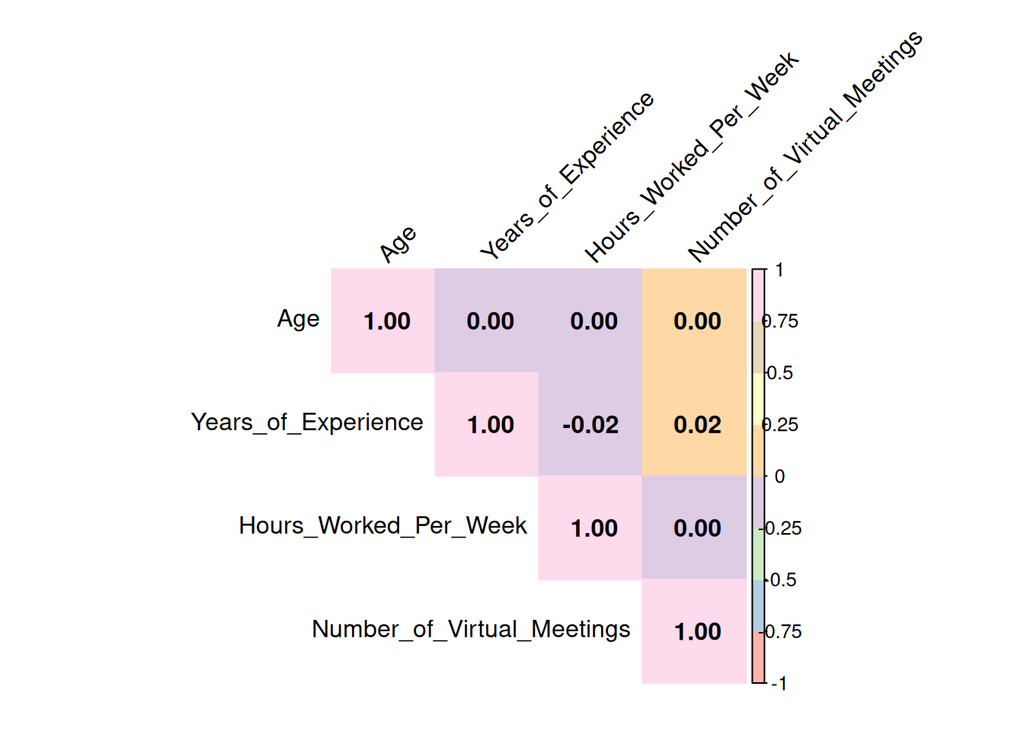

```r
# Crear el gráfico de correlación con colores pastel con los datos calculados anteriormente
corrplot(
  matriz_correlacion,
  method = "color",  # Representar correlaciones con colores
  col = brewer.pal(n = 8, name = "Pastel1"),  # Paleta pastel
  type = "upper",  # Mostrar solo la mitad superior de la matriz
  addCoef.col = "black",  # Añadir coeficientes en color negro
  tl.col = "black",  # Color de las etiquetas
  tl.srt = 45  # Girar las etiquetas 45 grados
)
```

## Distribución de la edad

**Código**

```r
grafico_edad <- ggplot(datos_limpios, aes(x = Age)) +
  geom_histogram(binwidth = 5, fill = "#3498db", color = "gray") +
  labs(title = "Edad participantes", x = "Edad", y = "Cantidad") +
  theme_minimal()

ggsave("../resultados/graficos/distribucion_edad.png", plot = grafico_edad)
```

**Código**

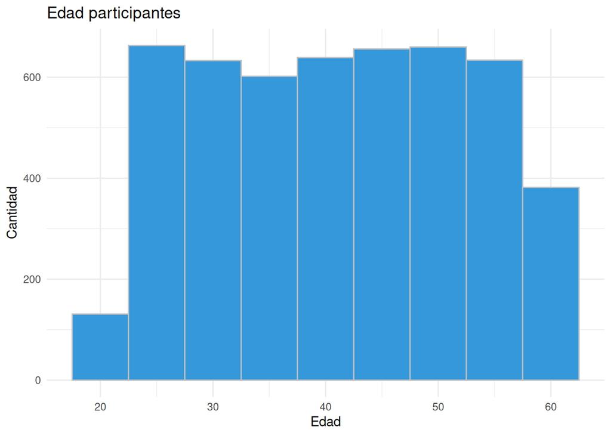

```r
grafico_edad
```

## Distribucion de genero

**Código**

```r
grafico_genero <- ggplot(datos, aes(x = Gender)) +
  geom_bar(fill = "#ccebc5") +  # Puedes cambiar el color según prefieras
  labs(title = "Genero participantes", x = "Sexo", y = "Cantidad") +
  theme_minimal()  # Estilo del gráfico
ggsave("../resultados/graficos/distribucion_genero.png", plot = grafico_genero)
```

**Código**

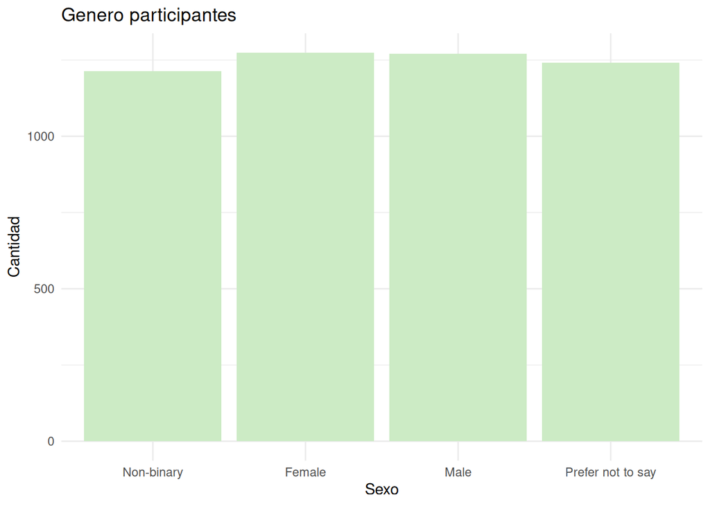

```r
grafico_genero
```

## Distribucion de rol laboral

**Código**

```r
grafico_rol_laboral <- ggplot(datos_limpios, aes(x = Job_Role)) +
  geom_bar(binwidth = 5, fill = "#decbe4") +
  labs(title = "Roles Laborales", x = "Rol Laboral", y = "Cantidad") +
  theme_minimal()
```

**Código**

```r
ggsave("../resultados/graficos/distribucion_rol_laboral.png", plot = grafico_rol_laboral)
```

**Código**

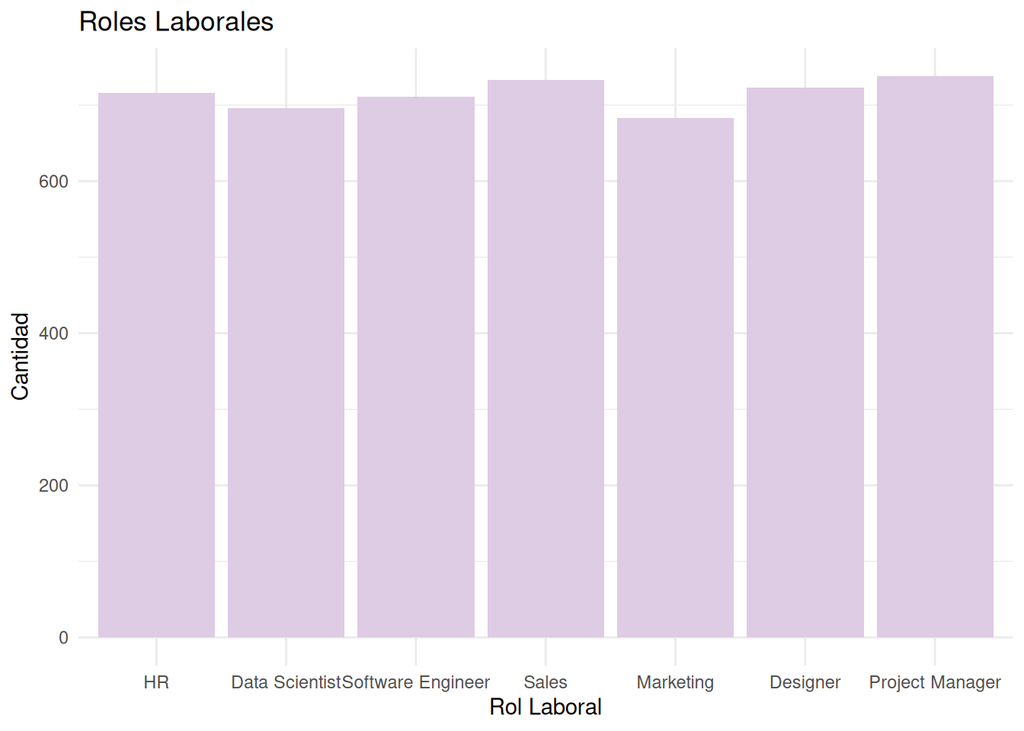

```r
grafico_rol_laboral
```

## Distribucion de industria

**Código**

```r
grafico_industria <- ggplot(datos_limpios, aes(x = Industry)) +
  geom_bar(binwidth = 5, fill = "#ffffcc", color = "gray") +
  labs(title = "Industrias de los participantes", x = "Industria", y = "Cantidad") +
  theme_minimal()
```

**Código**

```r
ggsave("../resultados/graficos/distribucion_industria.png", plot = grafico_industria)
```

**Código**

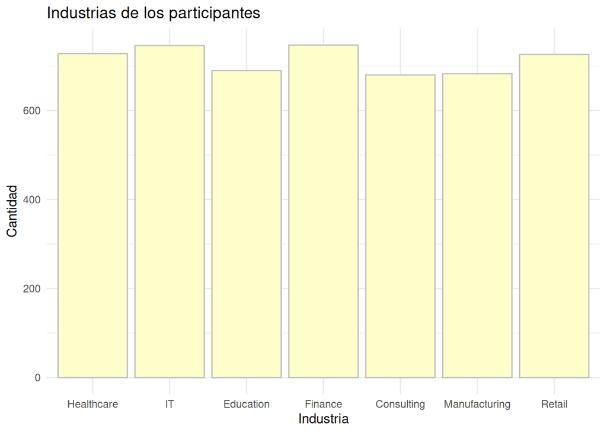

```r
grafico_industria
```

## Distribucion de años de experiencia por genero

**Código**

```r
datos_limpios <- datos_limpios %>%
  mutate(Genero = recode(Gender,
                         "Non-binary" = "No binario",
                         "Female" = "Femenino",
                         "Male" = "Masculino",
                         "Prefer not to say" = "Prefiero no decir"
  ))

grafico_experiencia <- ggplot(datos_limpios, aes(x = Genero, y = Years_of_Experience, fill = Genero)) +
  geom_boxplot(outlier.color = "gray") +
  labs(
    title = "Años de Experiencia por Género",
    y = "Años de Experiencia",
    x = "Género"
  ) +
  theme_minimal() +
  scale_fill_brewer(palette = "Pastel1")


ggsave("../resultados/graficos/distribucion_experiencia.png", plot = grafico_experiencia)
```

**Código**

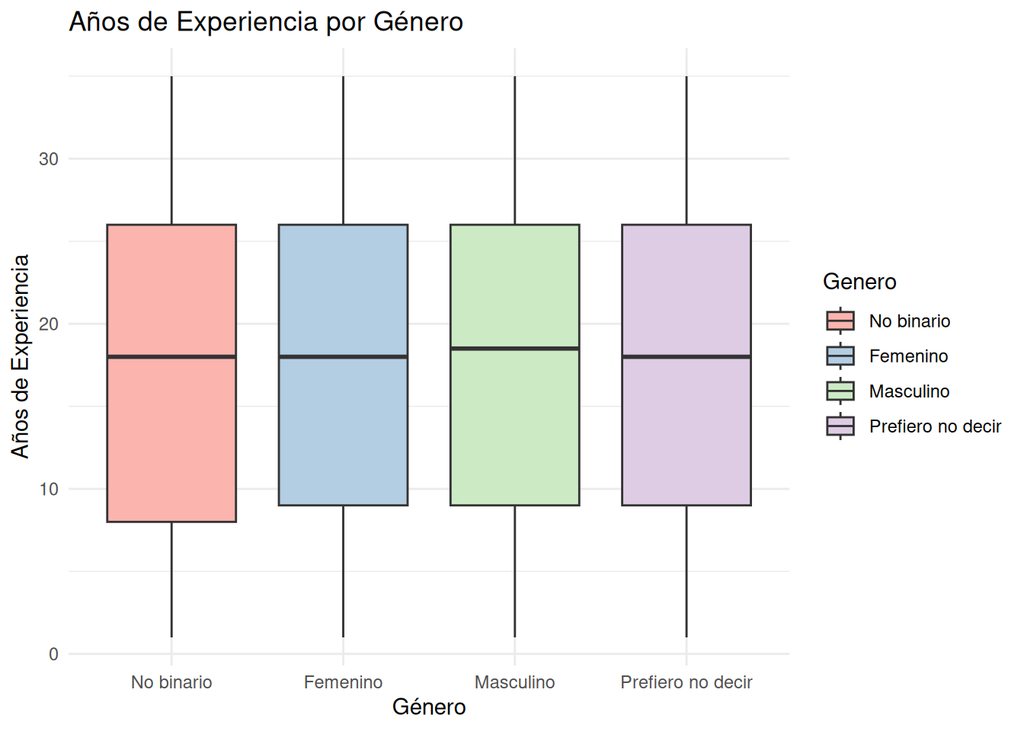

```r
grafico_experiencia
```

## Distribucion de ubicacion laboral

**Código**

```r
grafico_ubicacion<- ggplot(datos_limpios, aes(x = Work_Location)) +
  geom_bar(binwidth = 5, fill = "#f1948a", color = "gray") +
  labs(title = "Modalidad de trabajo", x = "Modalidad de trabajo", y = "Cantidad") +
  theme_minimal()
```

**Código**

```r
ggsave("../resultados/graficos/distribucion_ubicacion.png", plot = grafico_ubicacion)
```

**Código**

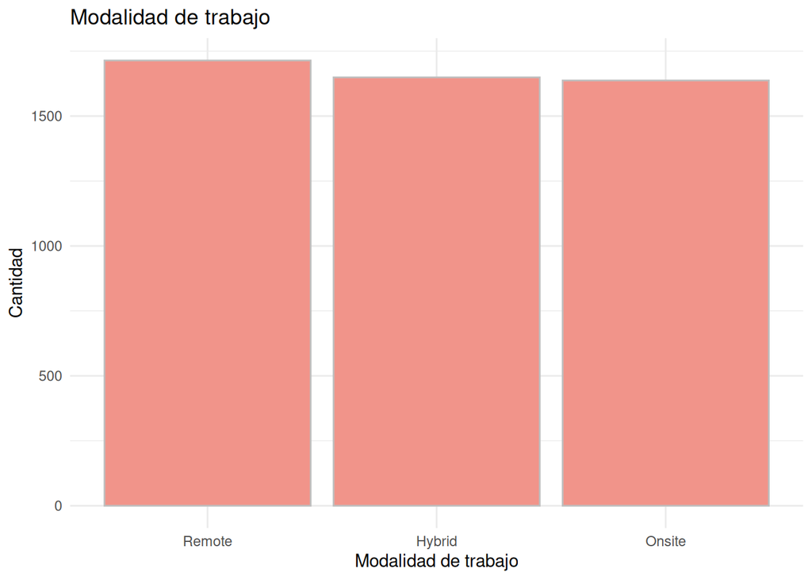

```r
grafico_ubicacion
```

## Distribucion de horas semanales trabajadas por modalidad laboral

**Código**

```r
grafico_horas_ubicacion <- ggplot(data = datos, aes(x = Work_Location, y = Hours_Worked_Per_Week)) +
  geom_boxplot(fill = "#58d68d", color = "darkgray") +  # Gráfico de caja
  labs(title = "Horas Semanales por Ubicación Laboral",
       x = "Ubicación Laboral",
       y = "Horas Trabajadas por Semana") +
  theme_minimal()  # Aplicar un tema minimalista
ggsave("../resultados/graficos/distribucion_horas_ubicacion.png", plot = grafico_horas_ubicacion)
```

**Código**

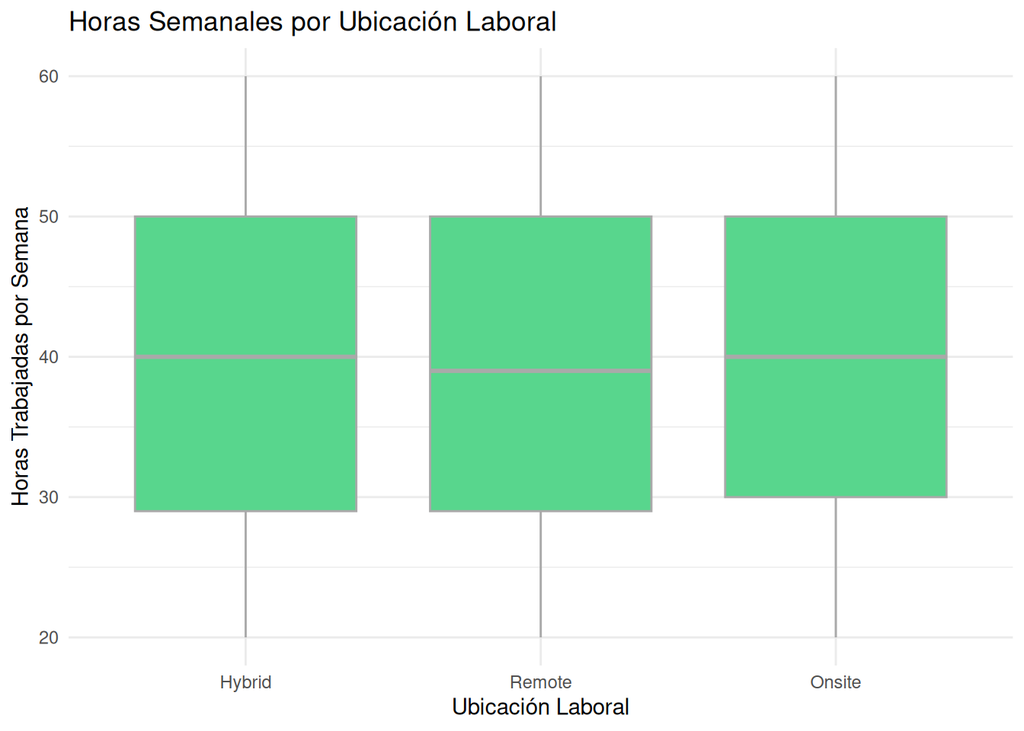

```r
grafico_horas_ubicacion
```

## Distribucion de numero de reuniones virtuales por ubicacion

**Código**

```r
grafico_reuniones_ubicacion  <- ggplot(data = datos, aes(x = Work_Location, y = Number_of_Virtual_Meetings)) +
  geom_boxplot(fill = "#f7dc6f", color = "gray") +  # Gráfico de caja
  labs(title = "Reuniones virtuales por Modalidad Laboral",
       x = "Modalidad Laboral",
       y = "Horas en reuniones virtuales") +
  theme_minimal()  # Aplicar un tema minimalista
ggsave("../resultados/graficos/distribucion_reuniones_ubicacion.png", plot = grafico_reuniones_ubicacion)
```

**Código**

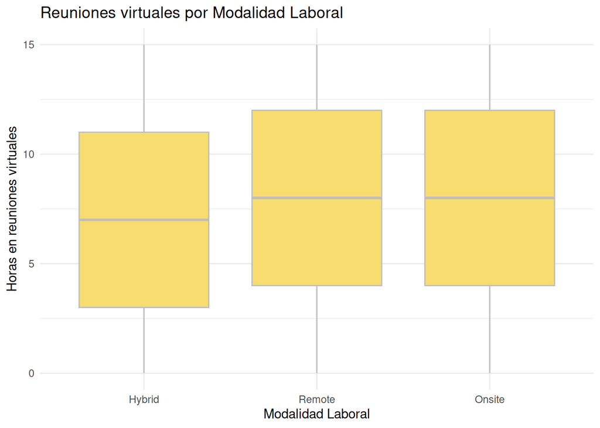

```r
grafico_reuniones_ubicacion
```

## Distribucion de balance vida por ubicacion

**Código**

```r
grafico_balance_ubicacion <- ggplot(datos) +
  geom_bar(aes(x = Work_Location, fill = Work_Life_Balance_Rating),
           position = "dodge") +  # Para que las barras no se apilen
  scale_fill_brewer(palette = "Pastel1") +  # Usar la paleta de colores pastel
  labs(
    title = "Modalidad laboral y Balance Vida-Trabajo",
    x = "Modalidad Laboral",
    y = "Cantidad",
    fill = "Balance Vida-Trabajo"
  ) +
  theme_minimal()  # Usar un tema minimalista para una apariencia limpia


ggsave("../resultados/graficos/distribucion_balance_ubicacion.png", plot = grafico_balance_ubicacion)
```

**Código**

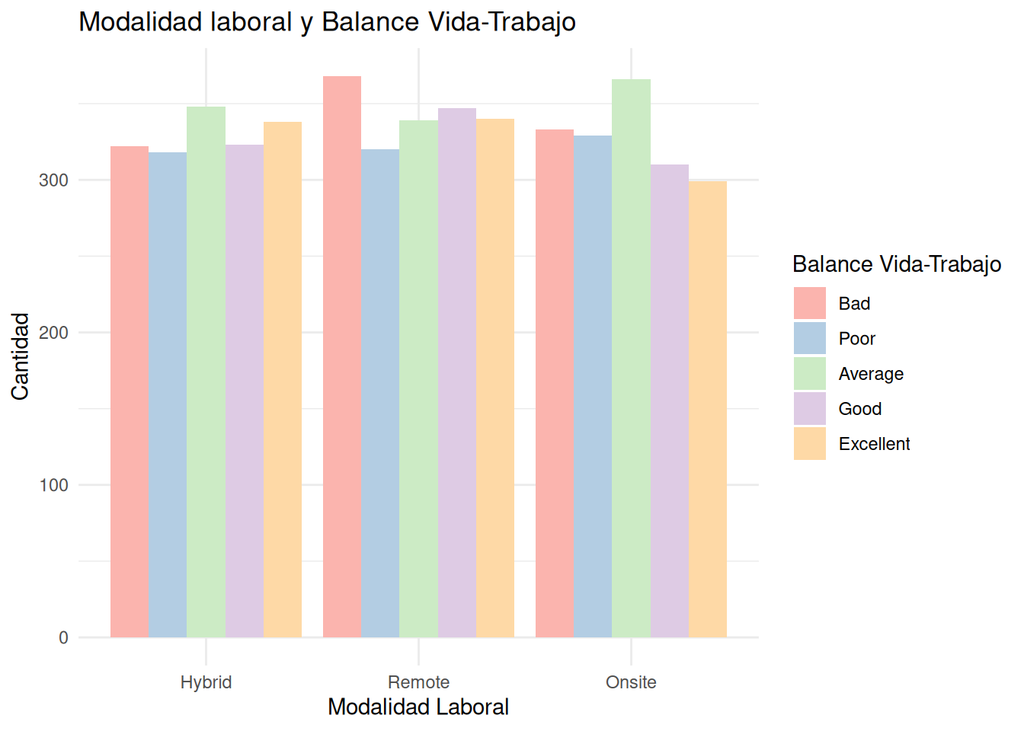

```r
grafico_balance_ubicacion
```

## Distribucion de nivel de estrés por ubicacion

**Código**

```r
grafico_estres_ubicacion <- ggplot(datos) +
  geom_bar(aes(x = Work_Location, fill = Stress_Level),
           position = "dodge") +  # Para que las barras no se apilen
  scale_fill_brewer(palette = "Pastel1") +  # Usar la paleta de colores pastel
  labs(
    title = "Modalidad Laboral y Nivel de estres",
    x = "Modalidad Laboral",
    y = "Cantidad",
    fill = "Nivel de estres"
  ) +
  theme_minimal()  # Usar un tema minimalista para una apariencia limpia

ggsave("../resultados/graficos/distribucion_estres_ubicacion.png", plot = grafico_estres_ubicacion)
```

**Código**

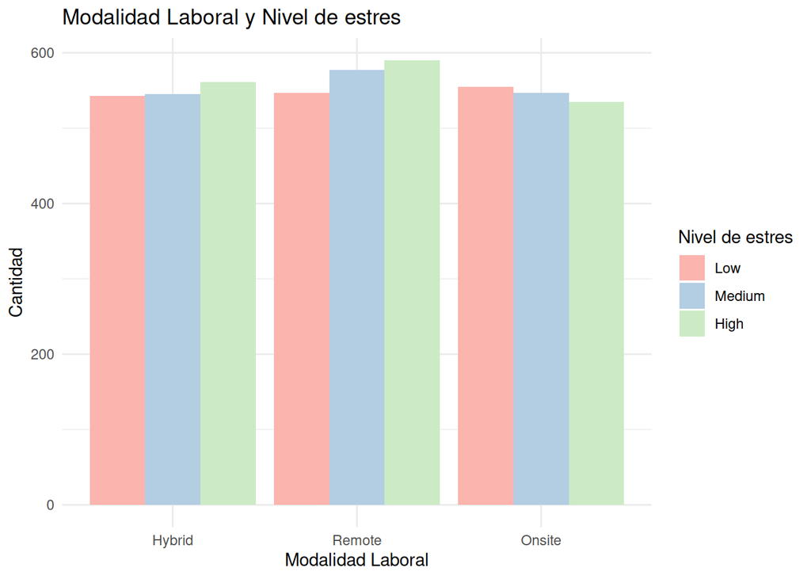

```r
grafico_estres_ubicacion
```

## Distribucion de estado de salud mental

**Código**

```r
grafico_salud_mental <- ggplot(datos_limpios, aes(x = Mental_Health_Condition)) +
  geom_bar(binwidth = 5, fill = "#6c3483", color = "gray") +
  labs(title = "Estado de Salud mental", x = "Salud Mental", y = "Cantidad") +
  theme_minimal()
```

**Código**

```r
ggsave("../resultados/graficos/distribucion_salud_mental.png", plot = grafico_salud_mental)
```

**Código**

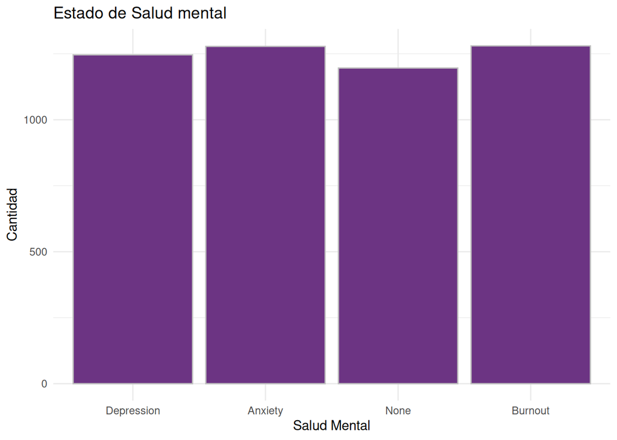

```r
grafico_salud_mental
```

## Distribucion de estado de salud mental por ubicacion

**Código**

```r
grafico_salud_mental_ubicacion <- ggplot(datos) +
  geom_bar(aes(x = Work_Location, fill = Mental_Health_Condition),
           position = "dodge") +  # Para que las barras no se apilen
  scale_fill_brewer(palette = "Pastel1") +  # Usar la paleta de colores pastel
  labs(
    title = "Modalidad laboral y Salud mental",
    x = "Modalidad laboral",
    y = "Cantidad",
    fill = "Salud mental"
  ) +
  theme_minimal()  # Usar un tema minimalista para una apariencia limpia

ggsave("../resultados/graficos/distribucion_salud_mental_ubicacion.png", plot = grafico_salud_mental_ubicacion)
```

**Código**

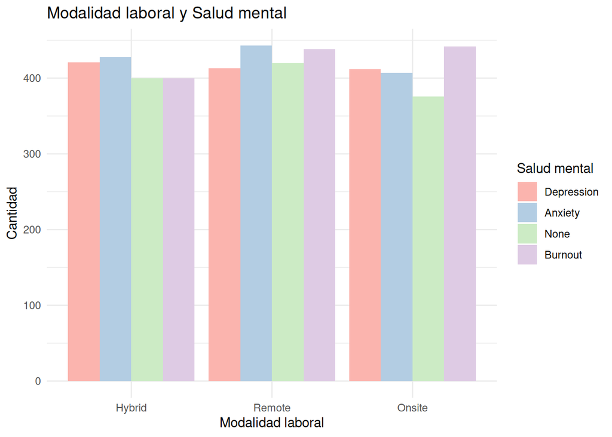

```r
grafico_salud_mental_ubicacion
```

## Distribucion de acceso a recursos de salud mental por ubicacion

**Código**

```r
grafico_acceso_recursos_ubicacion <- ggplot(datos) +
  geom_bar(aes(x = Work_Location, fill = Access_to_Mental_Health_Resources),
           position = "dodge") +  # Para que las barras no se apilen
  scale_fill_brewer(palette = "Pastel1") +  # Usar la paleta de colores pastel
  labs(
    title = "Modalidad laboral y Acceso a recursos de salud mental",
    x = "Modalidad laboral",
    y = "Cantidad",
    fill = "Acces a recursos "
  ) +
  theme_minimal()  # Usar un tema minimalista para una apariencia limpia

ggsave("../resultados/graficos/distribucion_acceso_recursos_ubicacion.png", plot = grafico_acceso_recursos_ubicacion)
```

**Código**

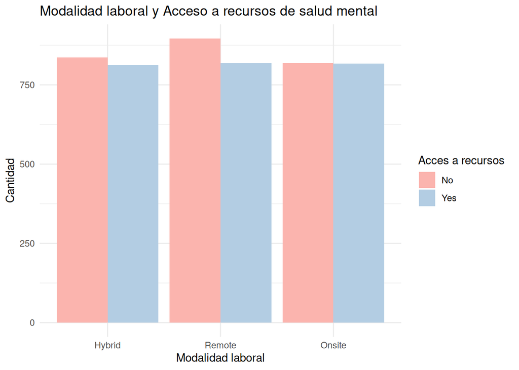

```r
grafico_acceso_recursos_ubicacion
```

## Distribucion de cambio en la productividad por ubicacion

**Código**

```r
# Calcular las frecuencias de las combinaciones de Work_Location y Productivity_Change
cant_productivity <- datos_limpios %>%
  count(Work_Location, Productivity_Change)

# Crear el gráfico con geom_tile para visualizar las frecuencias
grafico_productividad_ubicacion <- ggplot(data = cant_productivity) +
  aes(x = Work_Location, y = Productivity_Change, fill = n) +  # Mapear Work_Location y Productivity_Change
  geom_tile(colour = "white") +  # Agregar bordes blancos entre las celdas
  scale_y_discrete("Cambio de Productividad") +  # Etiqueta del eje y
  scale_x_discrete("Ubicación de Trabajo") +  # Etiqueta del eje x
  scale_fill_gradient(low = "lightgreen", high = "lightblue") +  # Escala de colores, puedes ajustar estos colores
  labs(
    title = "Productividad por Ubicación de Trabajo",
    fill = "Cantidad"  # Título de la leyenda
  ) +
  theme_minimal()  # Tema limpio para el gráfico


ggsave("../resultados/graficos/distribucion_prod_ubicacion.png", plot = grafico_productividad_ubicacion)
```

**Código**

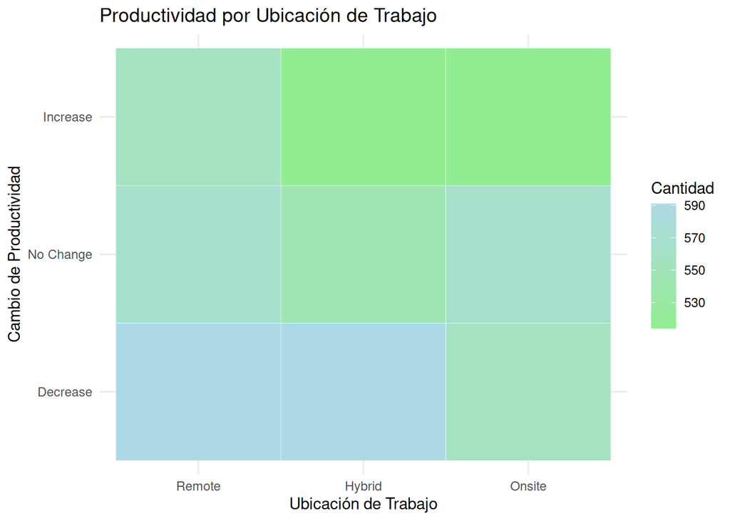

```r
grafico_productividad_ubicacion
```

## Grafico de aislamiento y ubicacion

**Código**

```r
# Paso 1: Calcular las frecuencias de las combinaciones de Work_Location y Social_Isolation_Rating
frecuencias_combinacion <- datos_limpios %>%
  count(Work_Location, Social_Isolation_Rating)

# Paso 2: Unir las frecuencias con el dataframe original
datos_limpios_con_frecuencias <- datos_limpios %>%
  left_join(frecuencias_combinacion, by = c("Work_Location", "Social_Isolation_Rating"))

# Paso 3: Crear el mapa de calor con geom_tile
grafico_aislamiento_ubicacion <- ggplot(data = datos_limpios_con_frecuencias) +
  aes(x = Work_Location, y = Social_Isolation_Rating, fill = n) +  # Mapear la frecuencia al color de relleno
  geom_tile(color = "white") +  # Crear las celdas con bordes blancos
  scale_fill_gradient(low = "#e8daef", high = "#4a235a") +  # Escala de colores basada en la frecuencia
  labs(title = "Aislamiento por Modalidad de trabajo", x = "Modalidad laboral", y = "Aislamiento Social", fill = "Cantidad") +  # Títulos de los ejes y leyenda
  theme_minimal() +  # Tema limpio
  theme(
      axis.text.x = element_text(angle = 90, vjust = 0.5, hjust = 1)  # Ajustar las etiquetas
    )

ggsave("../resultados/graficos/distribucion_aislam_ubicacion.png", plot = grafico_aislamiento_ubicacion)
```

**Código**

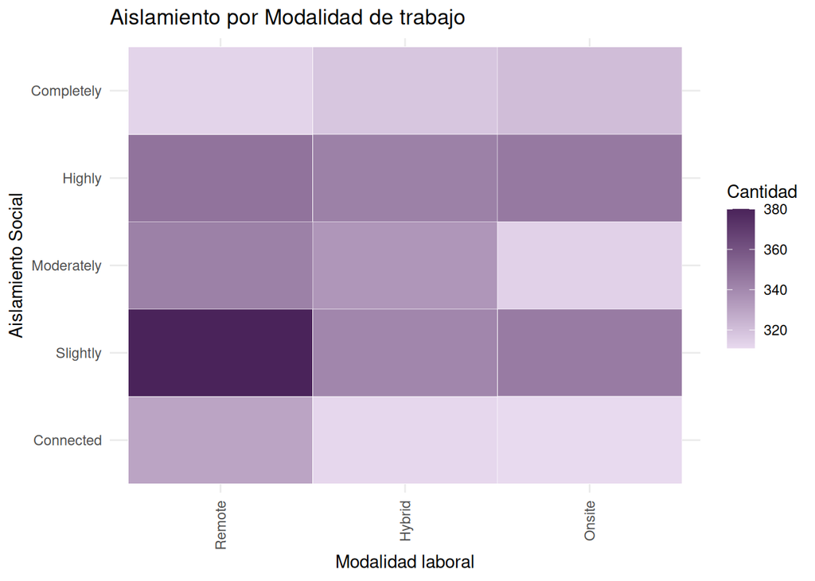

```r
grafico_aislamiento_ubicacion
```

## Distribucion de satisfaccion con el trabajo remoto por aislamiento social

**Código**

```r
# Paso 1: Calcular las frecuencias de las combinaciones de Social_Isolation_Rating y Satisfaction_with_Remote_Work
frecuencias_combinacion <- datos_limpios %>%
  count(Social_Isolation_Rating, Satisfaction_with_Remote_Work)

# Paso 2: Unir las frecuencias con el dataframe original
datos_limpios_con_frecuencias <- datos_limpios %>%
  left_join(frecuencias_combinacion, by = c("Social_Isolation_Rating", "Satisfaction_with_Remote_Work"))

# Paso 3: Crear el mapa de calor con geom_tile
grafico_aislamiento_satisfaccion <- ggplot(data = datos_limpios_con_frecuencias) +
  aes(x = Social_Isolation_Rating, y = Satisfaction_with_Remote_Work, fill = n) +  # Mapear la frecuencia al color de relleno
  geom_tile(color = "white") +  # Crear las celdas con bordes blancos
  scale_fill_gradient(low = "#f2d7d5", high = "#A50034") +  # Escala de colores basada en la frecuencia
  labs(x = "Aislamiento social", y = "Satisfaccion", fill = "Frecuencia") +  # Títulos de los ejes y leyenda
  theme_minimal() + # Tema limpio
  theme(
      axis.text.x = element_text(angle = 90, vjust = 0.5, hjust = 1)  # Ajustar las etiquetas
    )


ggsave("../resultados/graficos/distribucion_aislamiento_satisfaccion.png", plot = grafico_aislamiento_satisfaccion)
```

**Código**

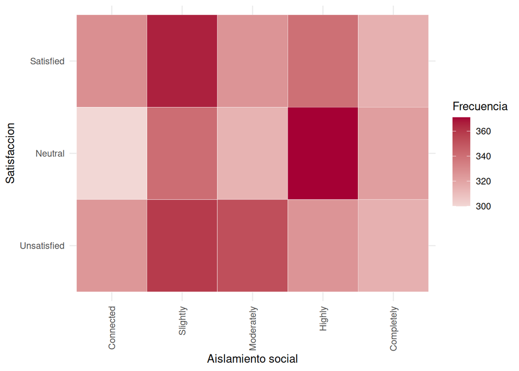

```r
grafico_aislamiento_satisfaccion
```

## Distribucion de soporte de la empresa para trabajo remoto

**Código**

```r
# Paso 1: Calcular las frecuencias de las combinaciones de Company_Support_for_Remote_Work y Work_Location
frecuencias_combinacion <- datos_limpios %>%
  count(Company_Support_for_Remote_Work, Work_Location)

# Paso 2: Unir las frecuencias con el dataframe original
datos_limpios_con_frecuencias <- datos_limpios %>%
  left_join(frecuencias_combinacion, by = c("Company_Support_for_Remote_Work", "Work_Location"))

# Paso 3: Crear el mapa de calor con geom_tile
grafico_frec_soporte_ubicacion <- ggplot(data = datos_limpios_con_frecuencias) +
  aes(x = Work_Location, y = Company_Support_for_Remote_Work, fill = n) +  # Mapear la frecuencia al color de relleno
  geom_tile(color = "white") +  # Crear las celdas con bordes blancos
  scale_fill_gradient(low = "#cfcfcf", high = "darkblue") +  # Escala de colores basada en la frecuencia
  labs(title = "Soporte para trabajo remoto", x = "Modalidad laboral", y = "Soporte Trabajo Remoto", fill = "Frecuencia") +  # Títulos de los ejes y leyenda
  theme_minimal() + # Tema limpio
  theme(
      axis.text.x = element_text(angle = 90, vjust = 0.5, hjust = 1)  # Ajustar las etiquetas
    )

ggsave("../resultados/graficos/distribucion_frec_soporte_ubicacion.png", plot = grafico_frec_soporte_ubicacion)
```

**Código**

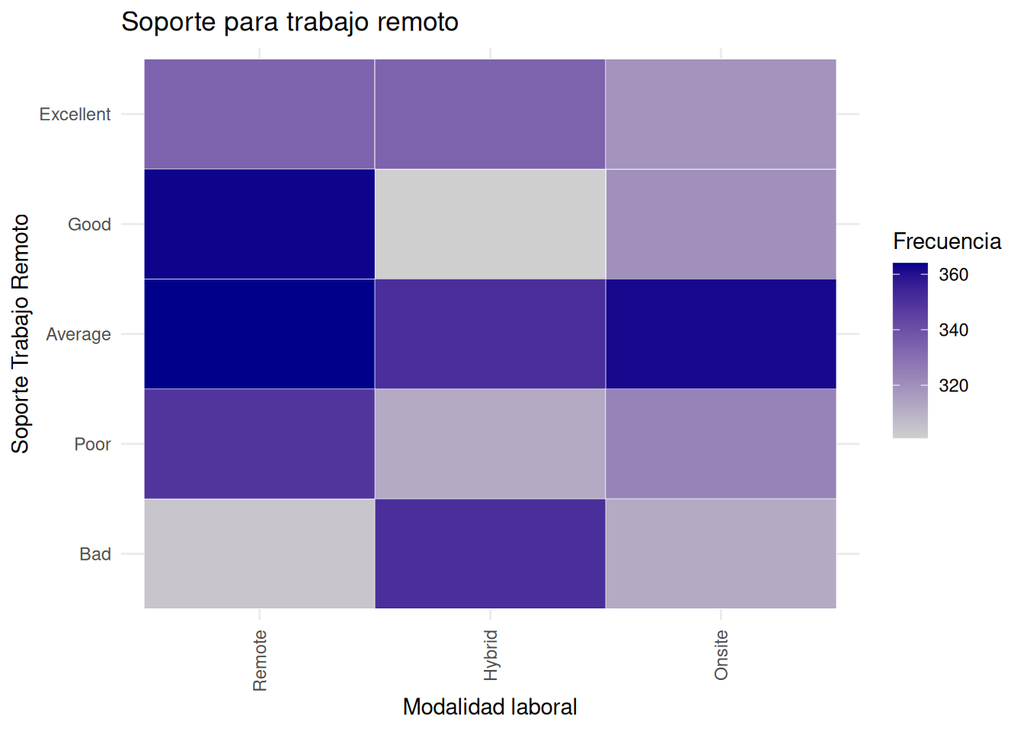

```r
grafico_frec_soporte_ubicacion
```